# Exercise 1: Intro to data modeling

your name

2021-04-23

# Section A: Practice with Paintings dataset

## Using and interpreting linear models

We will use a subset of the Paris paintings dataset from lecture.

```r
paintings <- read_csv("data/paris-paintings.csv") %>%
  clean_names() %>%
  select(price, logprice,
         ends_with("_in"), # measurements
         is_landscape = lands_all, # whether a picture is landscape
         school_pntg, # school that painting comes from
         arch:other # the genre of the painting
  )
```

Before fitting a model, let’s plot the data.

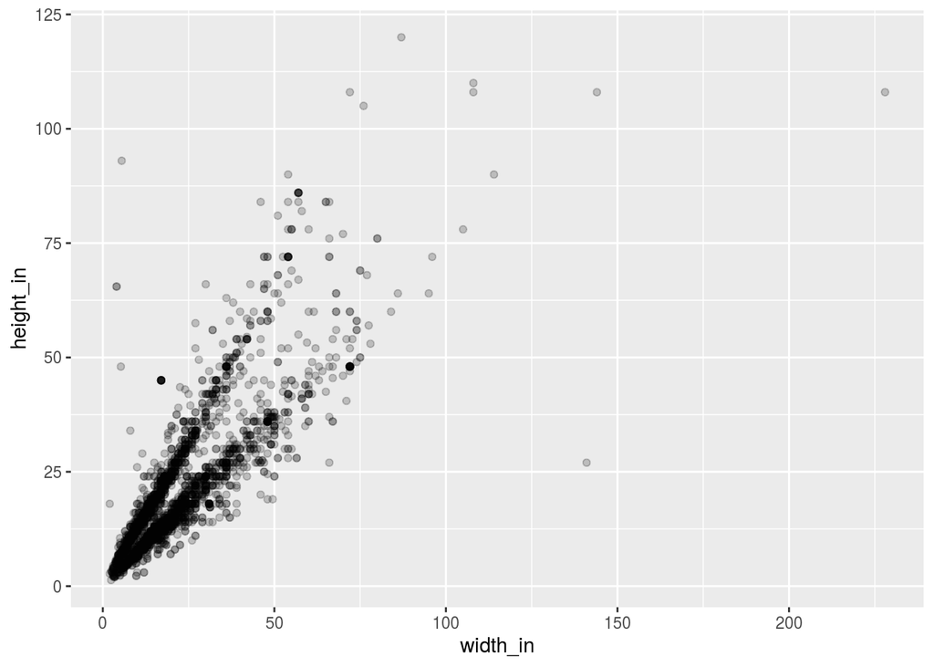

```r
measurements_scatter <- ggplot(paintings,
                               aes(x = width_in,
                                   y = height_in)) +
  geom_point(alpha = 0.2)
measurements_scatter
```

## Fit and tidy

The simple linear regression is of the form:

$$y_i=\beta_0+\beta_1x_{i}+\varepsilon_i, ~~~ i=1, \dots, n$$

To begin we are asking, how much variation in painting heights, the $y$ is explained by varation in painting widths, $x$.

```r
mod_heights <- lm(height_in ~ width_in, data = paintings)
mod_heights
```

```
##
## Call:
## lm(formula = height_in ~ width_in, data = paintings)
##
## Coefficients:
## (Intercept)     width_in
##      3.6214       0.7808
```

The formula `response ~ explanatory` specifies the reponse variable and explanatory variable from the data. In this case the response is height in inches and the explanatory variable is width_in. Note that by default the `lm()` function will include the intercept term.

We can extract components of the regression line using the `broom` package. The function `tidy()` will extract the estimated coefficients as a tidy table.

```r
coef_mod_heights <- tidy(mod_heights)
coef_mod_heights
```

```
## # A tibble: 2 x 5
##   term        estimate std.error statistic  p.value
##   <chr>          <dbl>     <dbl>     <dbl>    <dbl>
## 1 (Intercept)    3.62    0.254        14.3 8.82e-45
## 2 width_in       0.781   0.00950      82.1 0.
```

The fitted model has the following functional form:

$$\widehat{\text{height_in}} = 3.62 + 0.78width\_in$$

The coeffecients can be interpreted as

**Slope:** For each additional inch the painting is wider, the height is expected to be higher, on average, by 0.78 inches.

**Intercept:** Paintings that are 0 inches wide are expected to be 3.62 inches high, on average. (Question: Does this make sense?)

We can draw our fitted linear model with `geom_smooth(method = "lm")`

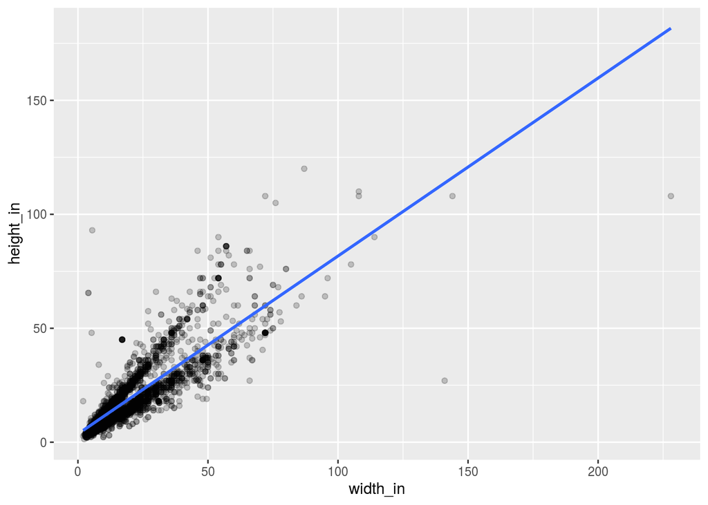

```r
measurements_scatter +
  geom_smooth(method = "lm", se = FALSE)
```

## Diagnostics and augment

The residuals from the model are the difference between the observed value and the fitted value. The residuals and fitted values can be extracted using `augment()` function from `broom`:

```r
mod_heights_diagnostics <- augment(mod_heights)
mod_heights_diagnostics
```

```
## # A tibble: 3,135 x 9
##    .rownames height_in width_in .fitted  .resid     .hat .sigma      .cooksd
##    <chr>         <dbl>    <dbl>   <dbl>   <dbl>    <dbl>  <dbl>        <dbl>
##  1 1                37     29.5   26.7  10.3    0.000399   8.30 0.000310
##  2 2                18     14     14.6   3.45   0.000396   8.31 0.0000342
##  3 3                13     16     16.1  -3.11   0.000361   8.31 0.0000254
##  4 4                14     18     17.7  -3.68   0.000337   8.31 0.0000330
##  5 5                14     18     17.7  -3.68   0.000337   8.31 0.0000330
##  6 6                 7     10     11.4  -4.43   0.000498   8.31 0.0000709
##  7 7                 6     13     13.8  -7.77   0.000418   8.30 0.000183
##  8 8                 6     13     13.8  -7.77   0.000418   8.30 0.000183
##  9 9                15     15     15.3  -0.333  0.000377   8.31 0.000000304
## 10 10                9      7      9.09 -0.0870 0.000601   8.31 0.0000000330
## # … with 3,125 more rows, and 1 more variable: .std.resid <dbl>
```

We can visualise the residuals directly on the scatter plot:

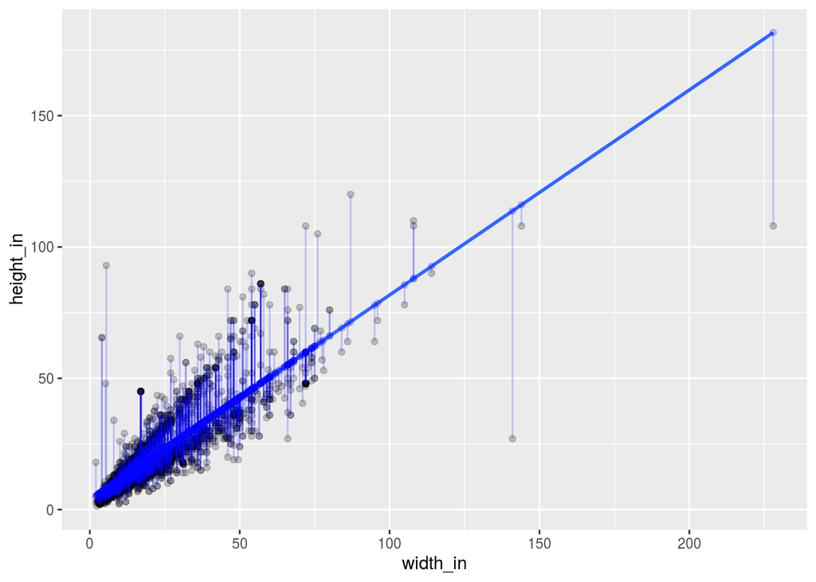

```r
measurements_scatter +
  geom_smooth(method = "lm", se = FALSE) +
  # overlay fitted values
  geom_point(data = mod_heights_diagnostics,
             aes(y = .fitted),
             color = "blue",
             alpha = 0.2) +
  # draw a line segment from the fitted value to observed value
  geom_segment(data = mod_heights_diagnostics,
               aes(xend = width_in, y = .fitted, yend = height_in),
               color = "blue",
               alpha = 0.2)
```

Another way of visualising of residuals to produce a scatterplot of the fitted values against the residuals:

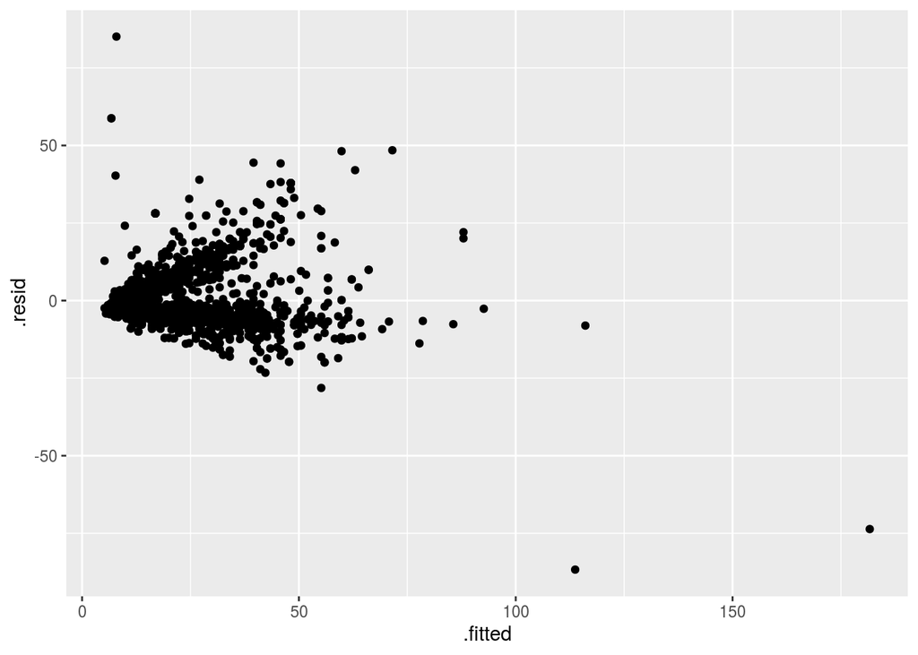

```r
ggplot(mod_heights_diagnostics,
       aes(x = .fitted, y = .resid)) +
  geom_point()
```

Yet, another and a better way to visualise residuals is using `resid_panel`

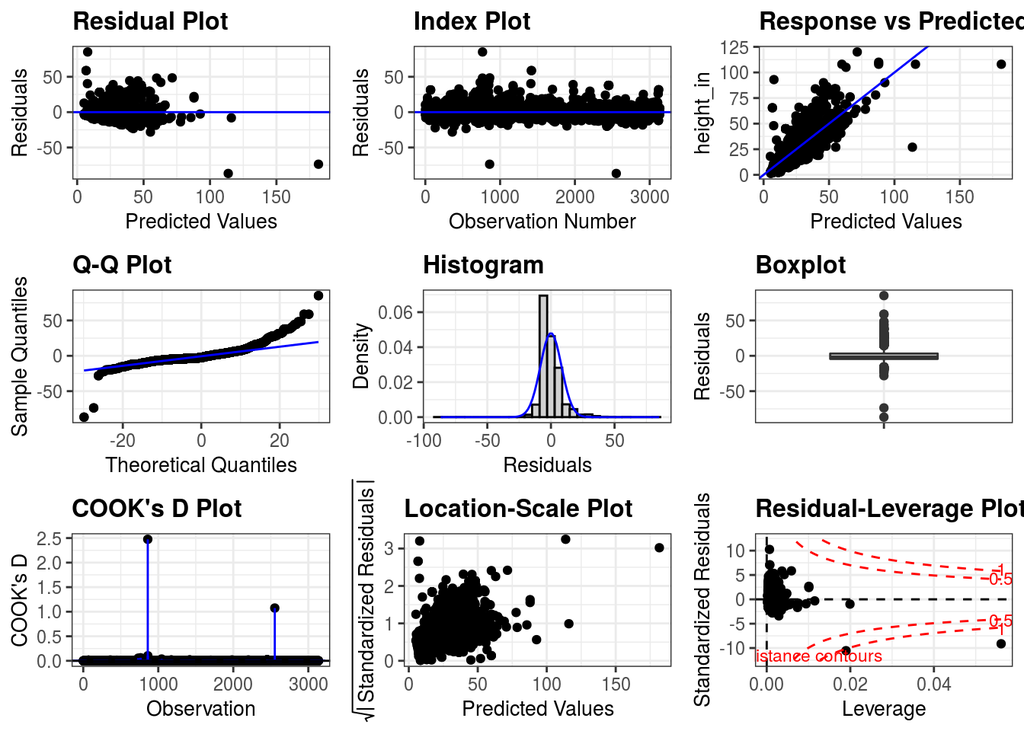

```r
library(ggResidpanel)
resid_panel(mod_heights, plots = "all")
```

Remember the assumptions of the linear model from lecture. What are they? Are they met from this plot?

Are there also observations with large positive residuals? What do they mean?

## How good is your fit? and glance

- $R^2$ is a common measurement of strength of linear model fit.
- $R^2$ tells us % variability in response explained by model.

We can extract model fit summaries using `glance()`

```r
mod_heights_summary <- glance(mod_heights)
mod_heights_summary
```

```
## # A tibble: 1 x 12
##   r.squared adj.r.squared sigma statistic p.value    df  logLik    AIC    BIC
##       <dbl>         <dbl> <dbl>     <dbl>   <dbl> <dbl>   <dbl>  <dbl>  <dbl>
## 1     0.683         0.683  8.30     6749.       0     1 -11083. 22173. 22191.
## # … with 3 more variables: deviance <dbl>, df.residual <int>, nobs <int>
```

The $R^2$ value here can be interpreted as the proportion of variance in heights explained by width. That is approximately 68% of variance in heights is explained by widths.

# Section B: Your turn with Categorical Predictor variable

Construct a linear model of heights as a function of one of the categorical genre variables, say `still_life`. Go through the process of interpretation, and checking the fit. Remember to set the variable to be a factor before running the model.

### Q1. Construct a linear model of heights as a function of one of the categorical genre variables, say `still_life`.

```r
paintings <- paintings %>%
  mutate(still_life = factor(still_life))

mod_heights_sl <- lm(height_in ~ still_life, data = paintings)
tidy(mod_heights_sl)
```

```
## # A tibble: 2 x 5
##   term        estimate std.error statistic p.value
##   <chr>          <dbl>     <dbl>     <dbl>   <dbl>
## 1 (Intercept)    20.5      0.268     76.4    0
## 2 still_life1     2.08     1.38       1.50   0.133
```

### Q2. How does it compare to the model we created above?

```r
mod_heights_sl_summary <- glance(mod_heights_sl)
mod_summary_all <- bind_rows(
  first = mod_heights_summary,
  second = mod_heights_sl_summary,
  .id = "model"
)

mod_summary_all
```

```
## # A tibble: 2 x 13
##   model  r.squared adj.r.squared sigma statistic p.value    df  logLik    AIC
##   <chr>      <dbl>         <dbl> <dbl>     <dbl>   <dbl> <dbl>   <dbl>  <dbl>
## 1 first   0.683         0.683     8.30   6749.     0         1 -11083. 22173.
## 2 second  0.000718      0.000400 14.7       2.26   0.133     1 -12906. 25817.
## # … with 4 more variables: BIC <dbl>, deviance <dbl>, df.residual <int>,
## #   nobs <int>
```

Try fitting and checking one more model of heights yourself, here are some helpful pointers for using the formula syntax, when adding more variables.

- `y ~ x1+x2+x3` three explanatory variables to be used to model response,
- `y ~ x - 1` specifies to force model to go through 0, that $b_0$ will be set to 0.

### What a model says

- The fitted model allows us to predict a value for the response, e.g.
  - Suppose $\widehat{y}=2+3x+x^2-2x^3$, then for $x=0.5, \widehat{y}=2+3*0.5+0.5^2-2*0.5^3=3.5$
  - Suppose $\widehat{y}=3\exp(2x)$, then for $x=-1, \widehat{y}=3\exp(2*(-1))=0.406$
- How useful the model prediction is depends on the residual error. If the model explains little of the relationship then the residual error will be large and predictions less useful.
- Predictions within the domain of the explanatory variables used to fit the model will be more reliable than **extrapolating** outside the domain. Particularly this is true for nonlinear models.

# Aside: what’s the difference between correlation and regression?

- Linear association between two variables can be described by correlation, **but**
- a multiple regression model can describe linear relationship between a response variable and **many** explanatory variables.

For two variables $X, Y$, correlation is:

$$r=\frac{\sum_{i=1}^{n} (x_i-\bar{x})(y_i-\bar{y})}{\sqrt{\sum_{i=1}^{n}(x_i-\bar{x})^2}\sqrt{\sum_{i=1}^{n}(y_i-\bar{y})^2}} = \frac{cov(X,Y)}{s_xs_y}$$

## Correlation

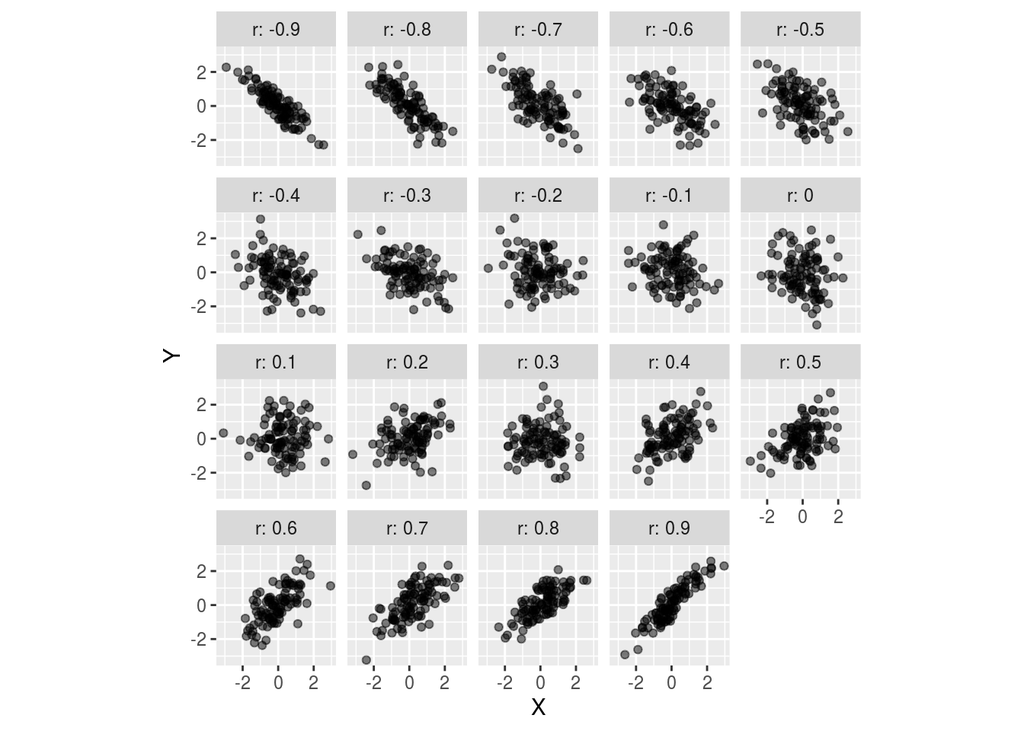

## Simple regression

$$y_i=\beta_0+\beta_1x_{i}+\varepsilon_i, ~~~ i=1, \dots, n$$
where (least squares) estimates for $\beta_0, \beta_1$ are:

$$b_1 = r\frac{s_y}{s_x}, ~~~~~~~~ b_0=\bar{y}-b_1\bar{x}$$

Slope is related to correlation, but it also depends on the variation of observations, in both of the variables.

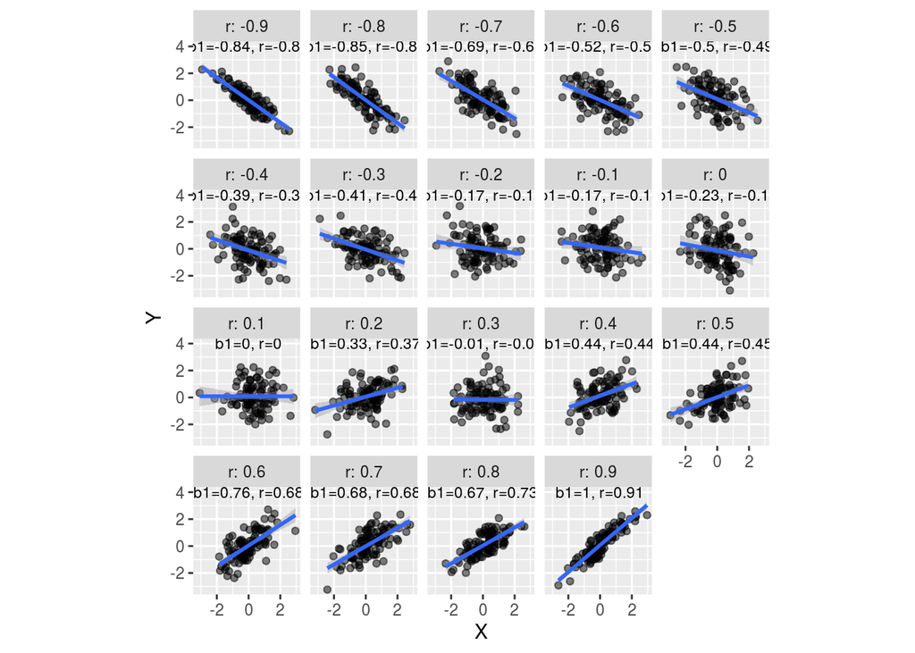

### Multiple regression model

$$y_i=\beta_0+\beta_1x_{i1}+\dots +\beta_px_{ip}+\varepsilon_i, ~~~ i=1, \dots, n$$

where $\varepsilon_i$ is distributed according to a normal distribution, $N(0, \sigma^2)$.

### Q3. From the plot below, answer the questions

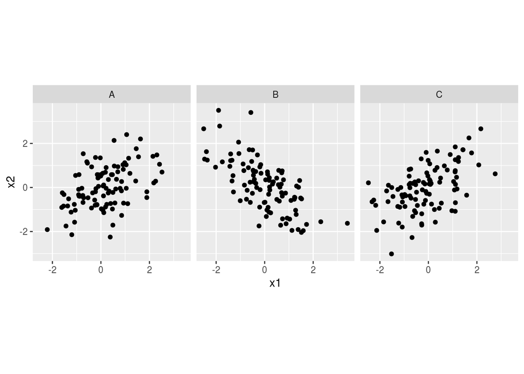